# ASM Chapter 4

code

julia

statistics

asm

ecology

Author

Dr Alun ap Rhisiart

Published

October 12, 2026

We turn to Chapter 4 of Applied Statistical Modelling for Ecologists, by Marc Kéry and Kenneth Kellner. In this chapter we turn to a comparison of different statistical modelling approaches for ecological data. The book considers jagsUI, NIMBLE, TMB, Stan, and Maximum Likelihood. I add Turing.jl to the mix, with a brief discussion of other Julia packages. The discussion of Maximum Likelihood Estimation in this chapter is the clearest I have encountered.

First we pull in any packages we will need.

```julia
using DataFramesMeta, Distributions, StatsBase, StatsPlots, RCall
```

Next, let’s make sure we have the exact same random variables as the book, for direct comparison. To ensure this, we actually call the R code itself, rather than using any of Julia’s RNGs.

```julia
R"""
set.seed(4)
y10 <- rnorm(n = 10, mean = 600, sd = 30) # Sample of 10 birds
y1000 <- rnorm(n = 1000, mean = 600, sd = 30)
"""
@rget y10 y1000

truth = (mean = 600, sd = 30)
first(y1000, 10)
```

```
10-element Vector{Float64}:
 616.9981349454094
 600.4715836201372
 611.4917201555145
 598.6458865226008
 601.0305572219098
 605.0708032265492
 634.9508051708302
 598.6738800824373
 596.9889467224228
 591.4966629337923
```

Next, eyeball the data, which will check that it looks the same as in the book.

[figure not shown]

```julia
p1 = histogram(
    y10,
    color = :grey,
    xlims = (500, 700),
    bins = 5,
    xlabel = "y10",
    ylabel = "Frequency",
    legend = false,
)

p2 = histogram(y1000, color = :grey, bins = 10, xlabel = "y1000", legend = false)

# Combine in a 1x2 layout
plot(p1, p2, layout = (1, 2), size = (800, 400))
```

## 4.3 The ‘Canned’ Example

For the ‘canned’ example, the book uses lm(). We can use GLM.jl for this. It takes an object that implements the Tables.jl inteface, not a vector, so we just wrap it in a DataFrame.

```julia
using GLM

y10lm = lm(@formula(y10 ~ 1), DataFrame(y10 = y10))
y1000lm = lm(@formula(y1000 ~ 1), DataFrame(y1000 = y1000))
y1000lm
```

```
StatsModels.TableRegressionModel{LinearModel{GLM.LmResp{Vector{Float64}}, GLM.DensePredChol{Float64, LinearAlgebra.CholeskyPivoted{Float64, Matrix{Float64}, Vector{Int64}}}}, Matrix{Float64}}

y1000 ~ 1

Coefficients:
────────────────────────────────────────────────────────────────────────
               Coef.  Std. Error       t  Pr(>|t|)  Lower 95%  Upper 95%
────────────────────────────────────────────────────────────────────────
(Intercept)  598.846    0.917595  652.63    <1e-99    597.045    600.647
────────────────────────────────────────────────────────────────────────
```

## 4.7.2 Maximum Likelihood Estimation

To keep in line with the book we will also do this manually, using idiomatic Julia where appropriate.

```julia
using Random, Optim, ForwardDiff, ADTypes

# Optim requires arrays of floats, not integers
starts = [550.0, 25.0]

# Objective Function (Negative Log-Likelihood)
function NLL(param, y)
    pop_mean = param[1]
    pop_sd = param[2]

    # Catch negative standard deviations so the optimizer doesn't crash
    if pop_sd <= 0.0
        return Inf
    end

    # Equivalent to -sum(dnorm(y, mean=pop_mean, sd=pop_sd, log=TRUE))
    return -loglikelihood(Normal(pop_mean, pop_sd), y)
end

# Optimize
# We use an anonymous function `p -> NLL(p, y1000)` to pass the data
# autodiff = AutoForwardDiff() calculates the gradients automatically for faster convergence
fm = optimize(p -> NLL(p, y1000), starts, LBFGS(), autodiff = AutoForwardDiff())

# Extract the maximum likelihood estimates
mle_estimates = Optim.minimizer(fm)
println("MLE Estimates (Mean, SD): ", mle_estimates)

# Calculate the Hessian at the minimum (equivalent to R's hessian=TRUE)
H = ForwardDiff.hessian(p -> NLL(p, y1000), mle_estimates)
println("Hessian Matrix:\n", H)
```

```
MLE Estimates (Mean, SD): [598.8460950752325, 29.002390678087444]
Hessian Matrix:
[1.188864620730756 6.827315404646025e-10; 6.827315179674075e-10 2.377729241796953]
```

The book now checks convergence, inverts the ‘Hessian’, and gets the standard errors for the parameter estimates. We can do the same in Julia as follows:

```julia
using LinearAlgebra

# Check convergence
converged = Optim.converged(fm)
println("Converged: ", converged)

# Invert the Hessian to get the covariance matrix
cov_matrix = inv(H)
println("Covariance Matrix:\n", cov_matrix)

# Standard errors for the parameter estimates
std_errors = sqrt.(diag(cov_matrix))
println("Standard Errors (Mean, SD): ", std_errors)
```

```
Converged: true
Covariance Matrix:
[0.8411386650444126 -2.415211481758575e-10; -2.415211402173144e-10 0.420569332462874]
Standard Errors (Mean, SD): [0.9171361213279153, 0.6485131706163523]
```

## The Turing.jl model

This is the main point about using Julia for Bayesian statistics. Let’s build the same model in Turing.jl. Here, I’m including pop_var as a variable to track, but not estimate. We do this with the `:=` operator, which defines a deterministic relationship in the model. However, for a situation like this I would normally calculate this after the sampling, as shown below.

### A note on priors

As I noted in the post about Chapter 3, while several distributions were introduced I was puzzled that Beta, Gamma, Exponential, and Cauchy were left out, and wondered what the priors would be like in later chapters. What we see in Chapter 4 and several later chapters is that the prior for sigma is Uniform for the JAGS examples, but half-Cauchy in the Stan example. Why is that? The purpose of using a Uniform prior is to be non-informative with a bounded range. However, Gelman (2006) showed that a Uniform prior on sigma is not truly non-informative, it has too much mass at higher values. The Cauchy distribution is the Student’s t distribution with one degree of freedom. The half-Cauchy is bounded by 0 with thick tails, and has desirable regularization properties for scale parameters. However, JAGS struggles with the thick tails, so is often replaced with a Uniform prior in JAGS examples.

Since Turing is a HMC sampler (like Stan), I use the half-Cauchy here and in later chapters. However, the Stan team now recommends using an Exponential prior for scale parameters instead of the half-Cauchy, as it provides similar regularization properties with lighter tails and better computational behavior. Since this is a tutorial and we are following the book closely, I will stick with the half-Cauchy for consistency.

```julia
using Turing, FlexiChains, MCMCDiagnosticTools

@model function model_4_4(mass)
    # Priors
    # Note: BUGS dnorm(0, 0.0001) uses precision τ = 0.0001,
    # which corresponds to variance 10,000 or SD = 100 in Turing.
    pop_mean ~ Normal(0, 100)
    pop_sd ~ truncated(Cauchy(0, 10); lower=0)

    # Add derived quantity for variance if required
    pop_var := pop_sd^2

    # Likelihood (Vectorized)
    mass .~ Normal(pop_mean, pop_sd)
end

# Sampling
model = model_4_4(y1000)
chains = sample(model, NUTS(), MCMCThreads(), 10000, 4; progress = false)
```

After sampling, we can calculate the population variance from the posterior draws of the standard deviation rather than relying on the deterministic variable `pop_var` defined in the model.

```julia
pop_sd_draws = vec(Array(chains[:pop_sd]))
mean(pop_sd_draws .^ 2)
```

```
843.2177099960052
```

Keep in mind that this is a HMC/NUTS model, so equivalent to the Stan example. To me, at least, the model code is *far* more readable, and the steps needed to compile and run the model also short, simple, and easy to understand. More so than NIMBLE: no configure/build/compile/compile/run sequence, just define the model and sample. Yes, there is a single function to run NIMBLE, too, but then you can’t run in parallel. In Turing, the `sample()` function can take `MCMCThreads()` or `MCMCDistributed()`. And the model itself has no declaring of types, no defined sections for params and data, and the code is Julia, so it has the full range of Julia functions available. Also, there is no likelihood loop, because it can do broadcasting as normal, so it is even shorter than the JAGS model code.

**Note**

One thing to note is that, as it is Julia code, the order matters, unlike JAGS. You have to define variables before you can refer to them.

Now we can examine the posterior distribution of the parameters.

```julia
summarystats(chains)
```

```
╭─FlexiSummary (9 statistics) ─────────────────────────────────────────────────╮
│   iter    collapsed                                                          │
│   chain   collapsed                                                          │
│ ↓ stat  = [mean, std, mcse, ess_bulk, ess_tail, rhat, q5, q50, q95]          │
│                                                                              │
│ Parameters (3) ── AbstractPPL.VarName                                        │
│  Float64  pop_mean, pop_sd, pop_var                                          │
│                                                                              │
│ Extras (14)                                                                  │
│  Float64  n_steps, is_accept, acceptance_rate, log_density                   │
│           hamiltonian_energy, hamiltonian_energy_error                       │
│           max_hamiltonian_energy_error, tree_depth, numerical_error          │
│           step_size, nom_step_size, logprior, loglikelihood, logjoint        │
│                                                                              │
│ Summary                                                                      │
│  param     mean      std      mcse    …  q5        q50       q95             │
│  pop_mean  598.7966  0.9209   0.0048     597.2854  598.7919  600.3212        │
│  pop_sd    29.0309   0.6501   0.0034     27.9832   29.0165   30.1176         │
│  pop_var   843.2177  37.8028  0.1966     783.0585  841.9592  907.0693        │
╰──────────────────────────────────────────────────────────────────────────────╯
```

This closely matches the results from NIMBLE given in the book.

## Trace plots

Getting trace and density plots from the chains is very straightforward.

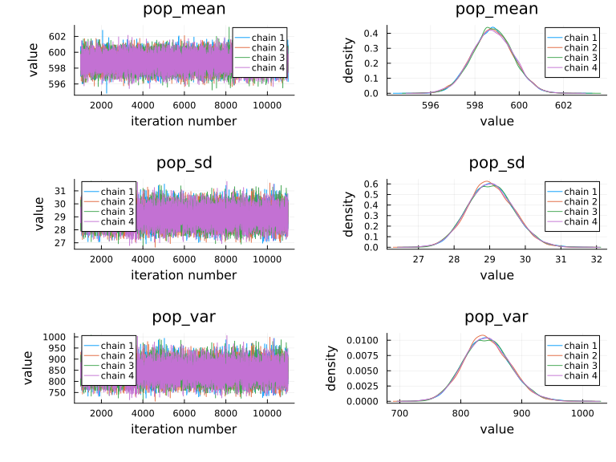

```julia
plot(chains; size = (800, 600))
```

There are lots of other plotting options, shown here: https://juliabayes.org/FlexiChains.jl/stable/plotting

Diagnostics can be any of the following (and more):

- `mean(chains)` # posterior mean for each parameter
- `median(chains)` # posterior median for each parameter
- `ess(chains)` # effective sample size for each parameter
- `rhat(chains)` # potential scale reduction factor for each parameter
- `mcse(chains)` # Monte Carlo standard error for each parameter

and more. We can also add posterior statistics from the PosteriorStats.jl package.

Finally, we can do Prior Predictive Checks and Posterior Predictive Checks. But as the chapter doesn’t mention them we will leave to a later model.

### Logical tests

For jagsUI (section 4.4.2) the book shows how to do straightforward logical tests, such as `mean(sims[,"pop.mean"] < 597)`. We can do a similar thing with Turing.

#### The direct vector extraction way

```julia
# Extract flattened vector of all posterior draws (e.g. 10,000 x 4 = 40,000 draws)
pop_mean_draws = vec(Array(chains[:pop_mean]))

# Calculate posterior probability P(pop_mean < 597)
prob = mean(pop_mean_draws .< 597)
```

```
0.02525
```

#### As a one-liner

```julia
# Direct one-liner
prob = mean(chains[:pop_mean] .< 597)
```

```
0.02525
```

## Other options besides Turing

The Julia ecosystem is a lot less mature than R. Turing itself is mature and stable, but other packages for Bayesian modeling may not be as fully developed or as user-friendly as their R counterparts.

### TuringGLM

I tried JuliaBUGS and TuringGLM as well, and could get neither to work. TuringGLM has just been archived, end of August 2026, in favour of newer packages. It would be the equivalent of brms. It is being replaced by TuringRegressions.jl and/or BayesianRegressionModels.jl, which I have not yet tried. There is also Soss.jl which seems to be a Julia interface to the Python library, so will not be considered here. I will try the other two packages and if successful, I will report my findings here.

### JuliaBUGS

If TuringGLM is the equivalent of brms, then JuliaBUGS is the equivalent of rjags or jagsui, providing an interface to the JAGS modelling language from within Julia. It does not call the R programs, but runs on top of Turing.jl. This sounds great for someone coming from R. Even better, it refers to a subpackage in R which would allow R users to run their model in Julia. However, the documentation is messy and I could not get either this simple model to work nor the examples in the documentation. Therefore, I will not be considering JuliaBUGS further in this series.

### Gibbs Sampler

It is a shame that there is no direct equivalent to a Gibbs sampler in Julia, as they do make handling of discrete variables such as N-Mixture or occupancy models much easier. There *is* a Gibbs sampler, but it seems to be for combining different samplers within a single framework. However, there is an argument to be made that marginalisation is the best approach.

I note that Turing does support Particle Gibbs, but I don’t think that is quite the same use case. They provide AbstractMCMC as a common interface for MCMC samplers, which allows for flexibility in choosing different sampling algorithms, and it would seem not too difficult to have a Gibbs sampler for common ecological use cases to be built using it. There is, after all, a Metropolis-Hastings sampler. I’ll look into that possibility.